# Risk Factor Analysis

## Outcome Variable

**Outcome Variable:** wast_rec90d

## Predictor Variables

**Intervention Variable:** feducyrs

**Adjustment Set:**

unadjusted

## Stratifying Variables

The analysis was stratified on these variable(s):

- agecat
- studyid
- country

## Data Summary

| agecat | studyid | country | feducyrs | wast_rec90d | n_cell | n |
| --- | --- | --- | --- | --- | --- | --- |
| 0-24 months | ki0047075b-MAL-ED | BANGLADESH | High | 0 | 6 | 71 |
| 0-24 months | ki0047075b-MAL-ED | BANGLADESH | High | 1 | 12 | 71 |
| 0-24 months | ki0047075b-MAL-ED | BANGLADESH | Low | 0 | 9 | 71 |
| 0-24 months | ki0047075b-MAL-ED | BANGLADESH | Low | 1 | 19 | 71 |
| 0-24 months | ki0047075b-MAL-ED | BANGLADESH | Medium | 0 | 10 | 71 |
| 0-24 months | ki0047075b-MAL-ED | BANGLADESH | Medium | 1 | 15 | 71 |
| 0-24 months | ki0047075b-MAL-ED | INDIA | High | 0 | 7 | 103 |
| 0-24 months | ki0047075b-MAL-ED | INDIA | High | 1 | 22 | 103 |
| 0-24 months | ki0047075b-MAL-ED | INDIA | Low | 0 | 16 | 103 |
| 0-24 months | ki0047075b-MAL-ED | INDIA | Low | 1 | 30 | 103 |
| 0-24 months | ki0047075b-MAL-ED | INDIA | Medium | 0 | 14 | 103 |
| 0-24 months | ki0047075b-MAL-ED | INDIA | Medium | 1 | 14 | 103 |
| 0-24 months | ki0047075b-MAL-ED | NEPAL | High | 0 | 2 | 37 |
| 0-24 months | ki0047075b-MAL-ED | NEPAL | High | 1 | 10 | 37 |
| 0-24 months | ki0047075b-MAL-ED | NEPAL | Low | 0 | 2 | 37 |
| 0-24 months | ki0047075b-MAL-ED | NEPAL | Low | 1 | 10 | 37 |
| 0-24 months | ki0047075b-MAL-ED | NEPAL | Medium | 0 | 4 | 37 |
| 0-24 months | ki0047075b-MAL-ED | NEPAL | Medium | 1 | 9 | 37 |
| 0-24 months | ki0047075b-MAL-ED | PERU | High | 0 | 2 | 26 |
| 0-24 months | ki0047075b-MAL-ED | PERU | High | 1 | 9 | 26 |
| 0-24 months | ki0047075b-MAL-ED | PERU | Low | 0 | 1 | 26 |
| 0-24 months | ki0047075b-MAL-ED | PERU | Low | 1 | 3 | 26 |
| 0-24 months | ki0047075b-MAL-ED | PERU | Medium | 0 | 1 | 26 |
| 0-24 months | ki0047075b-MAL-ED | PERU | Medium | 1 | 10 | 26 |
| 0-24 months | ki0047075b-MAL-ED | SOUTH AFRICA | High | 0 | 2 | 29 |
| 0-24 months | ki0047075b-MAL-ED | SOUTH AFRICA | High | 1 | 7 | 29 |
| 0-24 months | ki0047075b-MAL-ED | SOUTH AFRICA | Low | 0 | 3 | 29 |
| 0-24 months | ki0047075b-MAL-ED | SOUTH AFRICA | Low | 1 | 9 | 29 |
| 0-24 months | ki0047075b-MAL-ED | SOUTH AFRICA | Medium | 0 | 1 | 29 |
| 0-24 months | ki0047075b-MAL-ED | SOUTH AFRICA | Medium | 1 | 7 | 29 |

[output cut: 330 more lines]

The following strata were considered:

- agecat: 0-24 months, studyid: ki0047075b-MAL-ED, country: BANGLADESH
- agecat: 0-24 months, studyid: ki0047075b-MAL-ED, country: INDIA
- agecat: 0-24 months, studyid: ki0047075b-MAL-ED, country: NEPAL
- agecat: 0-24 months, studyid: ki0047075b-MAL-ED, country: PERU
- agecat: 0-24 months, studyid: ki0047075b-MAL-ED, country: SOUTH AFRICA
- agecat: 0-24 months, studyid: ki0047075b-MAL-ED, country: TANZANIA, UNITED REPUBLIC OF
- agecat: 0-24 months, studyid: ki1000304b-SAS-CompFeed, country: INDIA
- agecat: 0-24 months, studyid: ki1000304b-SAS-FoodSuppl, country: INDIA
- agecat: 0-24 months, studyid: ki1017093b-PROVIDE, country: BANGLADESH
- agecat: 0-24 months, studyid: ki1017093c-NIH-Crypto, country: BANGLADESH
- agecat: 0-24 months, studyid: ki1066203-TanzaniaChild2, country: TANZANIA, UNITED REPUBLIC OF
- agecat: 0-24 months, studyid: ki1113344-GMS-Nepal, country: NEPAL
- agecat: 0-24 months, studyid: ki1119695-PROBIT, country: BELARUS
- agecat: 0-24 months, studyid: ki1126311-ZVITAMBO, country: ZIMBABWE
- agecat: 0-24 months, studyid: ki1135781-COHORTS, country: GUATEMALA
- agecat: 0-24 months, studyid: ki1135781-COHORTS, country: INDIA
- agecat: 0-24 months, studyid: ki1135781-COHORTS, country: PHILIPPINES
- agecat: 0-24 months, studyid: ki1148112-LCNI-5, country: MALAWI
- agecat: 0-24 months, studyid: kiGH5241-JiVitA-3, country: BANGLADESH
- agecat: 0-24 months, studyid: kiGH5241-JiVitA-4, country: BANGLADESH
- agecat: 0-6 months, studyid: ki0047075b-MAL-ED, country: BANGLADESH
- agecat: 0-6 months, studyid: ki0047075b-MAL-ED, country: INDIA
- agecat: 0-6 months, studyid: ki0047075b-MAL-ED, country: NEPAL
- agecat: 0-6 months, studyid: ki0047075b-MAL-ED, country: PERU
- agecat: 0-6 months, studyid: ki0047075b-MAL-ED, country: SOUTH AFRICA
- agecat: 0-6 months, studyid: ki0047075b-MAL-ED, country: TANZANIA, UNITED REPUBLIC OF
- agecat: 0-6 months, studyid: ki1000304b-SAS-CompFeed, country: INDIA
- agecat: 0-6 months, studyid: ki1000304b-SAS-FoodSuppl, country: INDIA
- agecat: 0-6 months, studyid: ki1017093b-PROVIDE, country: BANGLADESH
- agecat: 0-6 months, studyid: ki1017093c-NIH-Crypto, country: BANGLADESH
- agecat: 0-6 months, studyid: ki1066203-TanzaniaChild2, country: TANZANIA, UNITED REPUBLIC OF
- agecat: 0-6 months, studyid: ki1113344-GMS-Nepal, country: NEPAL
- agecat: 0-6 months, studyid: ki1119695-PROBIT, country: BELARUS
- agecat: 0-6 months, studyid: ki1126311-ZVITAMBO, country: ZIMBABWE
- agecat: 0-6 months, studyid: ki1135781-COHORTS, country: GUATEMALA
- agecat: 0-6 months, studyid: ki1135781-COHORTS, country: INDIA
- agecat: 0-6 months, studyid: ki1135781-COHORTS, country: PHILIPPINES
- agecat: 0-6 months, studyid: ki1148112-LCNI-5, country: MALAWI
- agecat: 0-6 months, studyid: kiGH5241-JiVitA-3, country: BANGLADESH
- agecat: 0-6 months, studyid: kiGH5241-JiVitA-4, country: BANGLADESH
- agecat: 6-24 months, studyid: ki0047075b-MAL-ED, country: BANGLADESH
- agecat: 6-24 months, studyid: ki0047075b-MAL-ED, country: INDIA
- agecat: 6-24 months, studyid: ki0047075b-MAL-ED, country: NEPAL
- agecat: 6-24 months, studyid: ki0047075b-MAL-ED, country: PERU
- agecat: 6-24 months, studyid: ki0047075b-MAL-ED, country: SOUTH AFRICA
- agecat: 6-24 months, studyid: ki0047075b-MAL-ED, country: TANZANIA, UNITED REPUBLIC OF
- agecat: 6-24 months, studyid: ki1000304b-SAS-CompFeed, country: INDIA
- agecat: 6-24 months, studyid: ki1000304b-SAS-FoodSuppl, country: INDIA
- agecat: 6-24 months, studyid: ki1017093b-PROVIDE, country: BANGLADESH
- agecat: 6-24 months, studyid: ki1017093c-NIH-Crypto, country: BANGLADESH
- agecat: 6-24 months, studyid: ki1066203-TanzaniaChild2, country: TANZANIA, UNITED REPUBLIC OF
- agecat: 6-24 months, studyid: ki1113344-GMS-Nepal, country: NEPAL
- agecat: 6-24 months, studyid: ki1119695-PROBIT, country: BELARUS
- agecat: 6-24 months, studyid: ki1126311-ZVITAMBO, country: ZIMBABWE
- agecat: 6-24 months, studyid: ki1135781-COHORTS, country: GUATEMALA
- agecat: 6-24 months, studyid: ki1135781-COHORTS, country: INDIA
- agecat: 6-24 months, studyid: ki1135781-COHORTS, country: PHILIPPINES
- agecat: 6-24 months, studyid: ki1148112-LCNI-5, country: MALAWI
- agecat: 6-24 months, studyid: kiGH5241-JiVitA-3, country: BANGLADESH
- agecat: 6-24 months, studyid: kiGH5241-JiVitA-4, country: BANGLADESH

### Dropped Strata

Some strata were dropped due to rare outcomes:

- agecat: 0-24 months, studyid: ki0047075b-MAL-ED, country: NEPAL
- agecat: 0-24 months, studyid: ki0047075b-MAL-ED, country: PERU
- agecat: 0-24 months, studyid: ki0047075b-MAL-ED, country: SOUTH AFRICA
- agecat: 0-24 months, studyid: ki0047075b-MAL-ED, country: TANZANIA, UNITED REPUBLIC OF
- agecat: 0-24 months, studyid: ki1000304b-SAS-FoodSuppl, country: INDIA
- agecat: 0-24 months, studyid: ki1148112-LCNI-5, country: MALAWI
- agecat: 0-6 months, studyid: ki0047075b-MAL-ED, country: BANGLADESH
- agecat: 0-6 months, studyid: ki0047075b-MAL-ED, country: INDIA
- agecat: 0-6 months, studyid: ki0047075b-MAL-ED, country: NEPAL
- agecat: 0-6 months, studyid: ki0047075b-MAL-ED, country: PERU
- agecat: 0-6 months, studyid: ki0047075b-MAL-ED, country: SOUTH AFRICA
- agecat: 0-6 months, studyid: ki0047075b-MAL-ED, country: TANZANIA, UNITED REPUBLIC OF
- agecat: 0-6 months, studyid: ki1000304b-SAS-FoodSuppl, country: INDIA
- agecat: 0-6 months, studyid: ki1017093c-NIH-Crypto, country: BANGLADESH
- agecat: 0-6 months, studyid: ki1148112-LCNI-5, country: MALAWI
- agecat: 6-24 months, studyid: ki0047075b-MAL-ED, country: BANGLADESH
- agecat: 6-24 months, studyid: ki0047075b-MAL-ED, country: NEPAL
- agecat: 6-24 months, studyid: ki0047075b-MAL-ED, country: PERU
- agecat: 6-24 months, studyid: ki0047075b-MAL-ED, country: SOUTH AFRICA
- agecat: 6-24 months, studyid: ki0047075b-MAL-ED, country: TANZANIA, UNITED REPUBLIC OF
- agecat: 6-24 months, studyid: ki1000304b-SAS-FoodSuppl, country: INDIA
- agecat: 6-24 months, studyid: ki1017093c-NIH-Crypto, country: BANGLADESH
- agecat: 6-24 months, studyid: ki1126311-ZVITAMBO, country: ZIMBABWE
- agecat: 6-24 months, studyid: ki1135781-COHORTS, country: GUATEMALA
- agecat: 6-24 months, studyid: ki1135781-COHORTS, country: INDIA
- agecat: 6-24 months, studyid: ki1148112-LCNI-5, country: MALAWI
- agecat: 6-24 months, studyid: kiGH5241-JiVitA-3, country: BANGLADESH

## Methods Detail

We’re interested in the causal parameters $E[Y_a]$ for all values of $a \in \mathcal{A}$. These parameters represent the mean outcome if, possibly contrary to fact, we intervened to set all units to have $A=a$. Under the randomization and positivity assumptions, these are identified by the statistical parameters $\psi_a=E_W[E_{Y|A,W}(Y|A=a,W)]$. In addition, we’re interested in the mean of $Y$, $E[Y]$ under no intervention (the observed mean). We will estimate these parameters by using SuperLearner to fit the relevant likelihood factors – $E_{Y|A,W}(Y|A=a,W)$ and $p(A=a|W)$, and then updating our likelihood fit using a joint TMLE.

For unadjusted analyses ($W=\{\}$), initial likelihoods were estimated using Lrnr_glm to estimate the simple $E(Y|A)$ and Lrnr_mean to estimate $p(A)$. For adjusted analyses, a small library containing Lrnr_glmnet, Lrnr_xgboost, and Lrnr_mean was used.

Having estimated these parameters, we will then use the delta method to estimate relative risks and attributable risks relative to a prespecified baseline level of $A$.

# Results Detail

## Results Plots

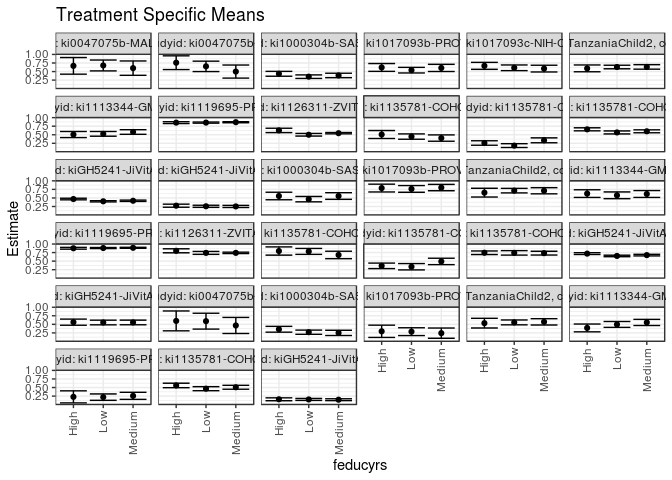

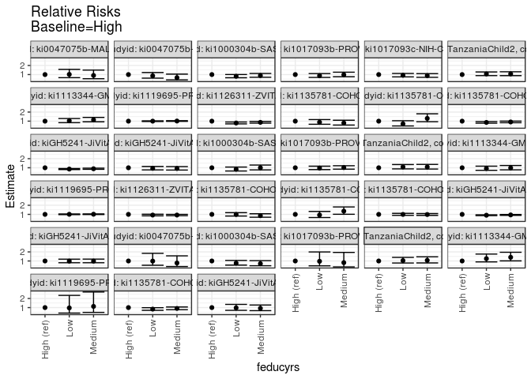

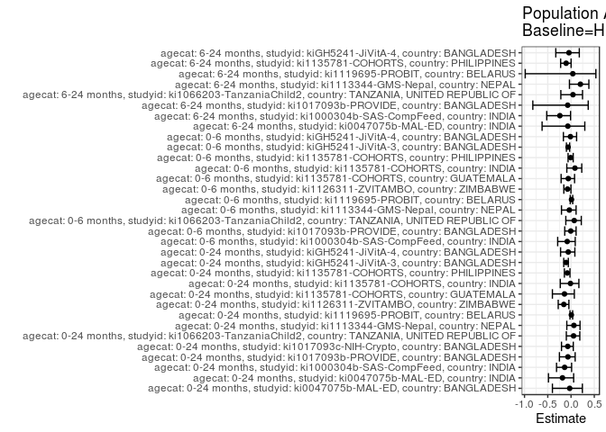

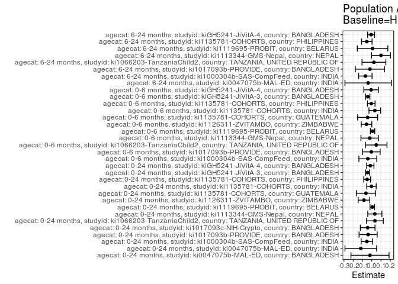

## Results Table

### Parameter: TSM

| agecat | studyid | country | intervention_level | baseline_level | estimate | ci_lower | ci_upper |
| --- | --- | --- | --- | --- | --- | --- | --- |
| 0-24 months | ki0047075b-MAL-ED | BANGLADESH | High | NA | 0.6666667 | 0.4235357 | 0.9097976 |
| 0-24 months | ki0047075b-MAL-ED | BANGLADESH | Low | NA | 0.6785714 | 0.5198822 | 0.8372607 |
| 0-24 months | ki0047075b-MAL-ED | BANGLADESH | Medium | NA | 0.6000000 | 0.3909534 | 0.8090466 |
| 0-24 months | ki0047075b-MAL-ED | INDIA | High | NA | 0.7586207 | 0.5584813 | 0.9587601 |
| 0-24 months | ki0047075b-MAL-ED | INDIA | Low | NA | 0.6521739 | 0.5001446 | 0.8042032 |
| 0-24 months | ki0047075b-MAL-ED | INDIA | Medium | NA | 0.5000000 | 0.3092033 | 0.6907967 |
| 0-24 months | ki1000304b-SAS-CompFeed | INDIA | High | NA | 0.4350000 | 0.3640111 | 0.5059889 |
| 0-24 months | ki1000304b-SAS-CompFeed | INDIA | Low | NA | 0.3512064 | 0.2998071 | 0.4026058 |
| 0-24 months | ki1000304b-SAS-CompFeed | INDIA | Medium | NA | 0.3865546 | 0.3218333 | 0.4512760 |
| 0-24 months | ki1017093b-PROVIDE | BANGLADESH | High | NA | 0.6202532 | 0.5057481 | 0.7347583 |
| 0-24 months | ki1017093b-PROVIDE | BANGLADESH | Low | NA | 0.5407407 | 0.4584564 | 0.6230251 |
| 0-24 months | ki1017093b-PROVIDE | BANGLADESH | Medium | NA | 0.6063830 | 0.5018667 | 0.7108993 |
| 0-24 months | ki1017093c-NIH-Crypto | BANGLADESH | High | NA | 0.6666667 | 0.5651059 | 0.7682275 |
| 0-24 months | ki1017093c-NIH-Crypto | BANGLADESH | Low | NA | 0.6101695 | 0.5275227 | 0.6928163 |
| 0-24 months | ki1017093c-NIH-Crypto | BANGLADESH | Medium | NA | 0.5862069 | 0.4874612 | 0.6849526 |
| 0-24 months | ki1066203-TanzaniaChild2 | TANZANIA, UNITED REPUBLIC OF | High | NA | 0.5929204 | 0.4934969 | 0.6923438 |
| 0-24 months | ki1066203-TanzaniaChild2 | TANZANIA, UNITED REPUBLIC OF | Low | NA | 0.6325459 | 0.5806938 | 0.6843981 |
| 0-24 months | ki1066203-TanzaniaChild2 | TANZANIA, UNITED REPUBLIC OF | Medium | NA | 0.6359447 | 0.5705844 | 0.7013050 |
| 0-24 months | ki1113344-GMS-Nepal | NEPAL | High | NA | 0.5064103 | 0.4178863 | 0.5949342 |
| 0-24 months | ki1113344-GMS-Nepal | NEPAL | Low | NA | 0.5261194 | 0.4575918 | 0.5946470 |
| 0-24 months | ki1113344-GMS-Nepal | NEPAL | Medium | NA | 0.5806452 | 0.5136526 | 0.6476378 |
| 0-24 months | ki1119695-PROBIT | BELARUS | High | NA | 0.8542945 | 0.8275205 | 0.8810685 |
| 0-24 months | ki1119695-PROBIT | BELARUS | Low | NA | 0.8547913 | 0.8382654 | 0.8713172 |
| 0-24 months | ki1119695-PROBIT | BELARUS | Medium | NA | 0.8667015 | 0.8514965 | 0.8819065 |
| 0-24 months | ki1126311-ZVITAMBO | ZIMBABWE | High | NA | 0.6266667 | 0.5625758 | 0.6907575 |
| 0-24 months | ki1126311-ZVITAMBO | ZIMBABWE | Low | NA | 0.5000000 | 0.4614867 | 0.5385133 |
| 0-24 months | ki1126311-ZVITAMBO | ZIMBABWE | Medium | NA | 0.5456630 | 0.5263330 | 0.5649929 |
| 0-24 months | ki1135781-COHORTS | GUATEMALA | High | NA | 0.5066667 | 0.3899457 | 0.6233876 |
| 0-24 months | ki1135781-COHORTS | GUATEMALA | Low | NA | 0.4465409 | 0.3687163 | 0.5243655 |
| 0-24 months | ki1135781-COHORTS | GUATEMALA | Medium | NA | 0.4032258 | 0.3103728 | 0.4960788 |

[output cut: 69 more lines]

### Parameter: E(Y)

| agecat | studyid | country | intervention_level | baseline_level | estimate | ci_lower | ci_upper |
| --- | --- | --- | --- | --- | --- | --- | --- |
| 0-24 months | ki0047075b-MAL-ED | BANGLADESH | NA | NA | 0.6478873 | 0.5336007 | 0.7621739 |
| 0-24 months | ki0047075b-MAL-ED | INDIA | NA | NA | 0.6407767 | 0.5352377 | 0.7463157 |
| 0-24 months | ki1000304b-SAS-CompFeed | INDIA | NA | NA | 0.3822441 | 0.3470990 | 0.4173892 |
| 0-24 months | ki1017093b-PROVIDE | BANGLADESH | NA | NA | 0.5811688 | 0.5245443 | 0.6377934 |
| 0-24 months | ki1017093c-NIH-Crypto | BANGLADESH | NA | NA | 0.6225806 | 0.5684562 | 0.6767051 |
| 0-24 months | ki1066203-TanzaniaChild2 | TANZANIA, UNITED REPUBLIC OF | NA | NA | 0.6272855 | 0.5895954 | 0.6649756 |
| 0-24 months | ki1113344-GMS-Nepal | NEPAL | NA | NA | 0.5397816 | 0.4973714 | 0.5821918 |
| 0-24 months | ki1119695-PROBIT | BELARUS | NA | NA | 0.8600563 | 0.8497279 | 0.8703846 |
| 0-24 months | ki1126311-ZVITAMBO | ZIMBABWE | NA | NA | 0.5425532 | 0.5258421 | 0.5592643 |
| 0-24 months | ki1135781-COHORTS | GUATEMALA | NA | NA | 0.4441341 | 0.3908676 | 0.4974005 |
| 0-24 months | ki1135781-COHORTS | INDIA | NA | NA | 0.2560297 | 0.2186976 | 0.2933617 |
| 0-24 months | ki1135781-COHORTS | PHILIPPINES | NA | NA | 0.6092757 | 0.5839352 | 0.6346162 |
| 0-24 months | kiGH5241-JiVitA-3 | BANGLADESH | NA | NA | 0.4230769 | 0.4117323 | 0.4344216 |
| 0-24 months | kiGH5241-JiVitA-4 | BANGLADESH | NA | NA | 0.2581128 | 0.2384369 | 0.2777888 |
| 0-6 months | ki1000304b-SAS-CompFeed | INDIA | NA | NA | 0.5147059 | 0.4610948 | 0.5683169 |
| 0-6 months | ki1017093b-PROVIDE | BANGLADESH | NA | NA | 0.7837838 | 0.7252863 | 0.8422812 |
| 0-6 months | ki1066203-TanzaniaChild2 | TANZANIA, UNITED REPUBLIC OF | NA | NA | 0.7029412 | 0.6536517 | 0.7522307 |
| 0-6 months | ki1113344-GMS-Nepal | NEPAL | NA | NA | 0.6045627 | 0.5449300 | 0.6641955 |
| 0-6 months | ki1119695-PROBIT | BELARUS | NA | NA | 0.8851500 | 0.8753163 | 0.8949836 |
| 0-6 months | ki1126311-ZVITAMBO | ZIMBABWE | NA | NA | 0.7459860 | 0.7286870 | 0.7632850 |
| 0-6 months | ki1135781-COHORTS | GUATEMALA | NA | NA | 0.7512438 | 0.6914852 | 0.8110023 |
| 0-6 months | ki1135781-COHORTS | INDIA | NA | NA | 0.3954155 | 0.3440450 | 0.4467860 |
| 0-6 months | ki1135781-COHORTS | PHILIPPINES | NA | NA | 0.7402032 | 0.7074271 | 0.7729793 |
| 0-6 months | kiGH5241-JiVitA-3 | BANGLADESH | NA | NA | 0.6767743 | 0.6631857 | 0.6903630 |
| 0-6 months | kiGH5241-JiVitA-4 | BANGLADESH | NA | NA | 0.5561798 | 0.5140008 | 0.5983587 |
| 6-24 months | ki0047075b-MAL-ED | INDIA | NA | NA | 0.5614035 | 0.4130317 | 0.7097753 |
| 6-24 months | ki1000304b-SAS-CompFeed | INDIA | NA | NA | 0.2866242 | 0.2446853 | 0.3285631 |
| 6-24 months | ki1017093b-PROVIDE | BANGLADESH | NA | NA | 0.2764228 | 0.1950773 | 0.3577682 |
| 6-24 months | ki1066203-TanzaniaChild2 | TANZANIA, UNITED REPUBLIC OF | NA | NA | 0.5579515 | 0.5056058 | 0.6102972 |
| 6-24 months | ki1113344-GMS-Nepal | NEPAL | NA | NA | 0.4947090 | 0.4399319 | 0.5494861 |
| 6-24 months | ki1119695-PROBIT | BELARUS | NA | NA | 0.2363636 | 0.1715730 | 0.3011543 |
| 6-24 months | ki1135781-COHORTS | PHILIPPINES | NA | NA | 0.5073446 | 0.4725123 | 0.5421770 |
| 6-24 months | kiGH5241-JiVitA-4 | BANGLADESH | NA | NA | 0.1497617 | 0.1318544 | 0.1676691 |

### Parameter: RR

| agecat | studyid | country | intervention_level | baseline_level | estimate | ci_lower | ci_upper |
| --- | --- | --- | --- | --- | --- | --- | --- |
| 0-24 months | ki0047075b-MAL-ED | BANGLADESH | High | High | 1.0000000 | 1.0000000 | 1.0000000 |
| 0-24 months | ki0047075b-MAL-ED | BANGLADESH | Low | High | 1.0178571 | 0.6597795 | 1.5702719 |
| 0-24 months | ki0047075b-MAL-ED | BANGLADESH | Medium | High | 0.9000000 | 0.5432668 | 1.4909800 |
| 0-24 months | ki0047075b-MAL-ED | INDIA | High | High | 1.0000000 | 1.0000000 | 1.0000000 |
| 0-24 months | ki0047075b-MAL-ED | INDIA | Low | High | 0.8596838 | 0.6045511 | 1.2224875 |
| 0-24 months | ki0047075b-MAL-ED | INDIA | Medium | High | 0.6590909 | 0.4141553 | 1.0488839 |
| 0-24 months | ki1000304b-SAS-CompFeed | INDIA | High | High | 1.0000000 | 1.0000000 | 1.0000000 |
| 0-24 months | ki1000304b-SAS-CompFeed | INDIA | Low | High | 0.8073711 | 0.6484480 | 1.0052435 |
| 0-24 months | ki1000304b-SAS-CompFeed | INDIA | Medium | High | 0.8886313 | 0.7033667 | 1.1226940 |
| 0-24 months | ki1017093b-PROVIDE | BANGLADESH | High | High | 1.0000000 | 1.0000000 | 1.0000000 |
| 0-24 months | ki1017093b-PROVIDE | BANGLADESH | Low | High | 0.8718065 | 0.6862517 | 1.1075333 |
| 0-24 months | ki1017093b-PROVIDE | BANGLADESH | Medium | High | 0.9776379 | 0.7592503 | 1.2588416 |
| 0-24 months | ki1017093c-NIH-Crypto | BANGLADESH | High | High | 1.0000000 | 1.0000000 | 1.0000000 |
| 0-24 months | ki1017093c-NIH-Crypto | BANGLADESH | Low | High | 0.9152542 | 0.7463097 | 1.1224432 |
| 0-24 months | ki1017093c-NIH-Crypto | BANGLADESH | Medium | High | 0.8793103 | 0.7005034 | 1.1037587 |
| 0-24 months | ki1066203-TanzaniaChild2 | TANZANIA, UNITED REPUBLIC OF | High | High | 1.0000000 | 1.0000000 | 1.0000000 |
| 0-24 months | ki1066203-TanzaniaChild2 | TANZANIA, UNITED REPUBLIC OF | Low | High | 1.0668312 | 0.8851883 | 1.2857477 |
| 0-24 months | ki1066203-TanzaniaChild2 | TANZANIA, UNITED REPUBLIC OF | Medium | High | 1.0725635 | 0.8810672 | 1.3056806 |
| 0-24 months | ki1113344-GMS-Nepal | NEPAL | High | High | 1.0000000 | 1.0000000 | 1.0000000 |
| 0-24 months | ki1113344-GMS-Nepal | NEPAL | Low | High | 1.0389193 | 0.8354603 | 1.2919266 |
| 0-24 months | ki1113344-GMS-Nepal | NEPAL | Medium | High | 1.1465904 | 0.9299731 | 1.4136642 |
| 0-24 months | ki1119695-PROBIT | BELARUS | High | High | 1.0000000 | 1.0000000 | 1.0000000 |
| 0-24 months | ki1119695-PROBIT | BELARUS | Low | High | 1.0005816 | 0.9644058 | 1.0381143 |
| 0-24 months | ki1119695-PROBIT | BELARUS | Medium | High | 1.0145231 | 0.9787312 | 1.0516240 |
| 0-24 months | ki1126311-ZVITAMBO | ZIMBABWE | High | High | 1.0000000 | 1.0000000 | 1.0000000 |
| 0-24 months | ki1126311-ZVITAMBO | ZIMBABWE | Low | High | 0.7978723 | 0.7019815 | 0.9068619 |
| 0-24 months | ki1126311-ZVITAMBO | ZIMBABWE | Medium | High | 0.8707388 | 0.7814104 | 0.9702789 |
| 0-24 months | ki1135781-COHORTS | GUATEMALA | High | High | 1.0000000 | 1.0000000 | 1.0000000 |
| 0-24 months | ki1135781-COHORTS | GUATEMALA | Low | High | 0.8813307 | 0.6601913 | 1.1765436 |
| 0-24 months | ki1135781-COHORTS | GUATEMALA | Medium | High | 0.7958404 | 0.5745804 | 1.1023034 |

[output cut: 69 more lines]

### Parameter: PAR

| agecat | studyid | country | intervention_level | baseline_level | estimate | ci_lower | ci_upper |
| --- | --- | --- | --- | --- | --- | --- | --- |
| 0-24 months | ki0047075b-MAL-ED | BANGLADESH | High | NA | -0.0187793 | -0.2243504 | 0.1867917 |
| 0-24 months | ki0047075b-MAL-ED | INDIA | High | NA | -0.1178440 | -0.2885817 | 0.0528938 |
| 0-24 months | ki1000304b-SAS-CompFeed | INDIA | High | NA | -0.0527559 | -0.1143052 | 0.0087935 |
| 0-24 months | ki1017093b-PROVIDE | BANGLADESH | High | NA | -0.0390843 | -0.1369234 | 0.0587547 |
| 0-24 months | ki1017093c-NIH-Crypto | BANGLADESH | High | NA | -0.0440860 | -0.1231324 | 0.0349603 |
| 0-24 months | ki1066203-TanzaniaChild2 | TANZANIA, UNITED REPUBLIC OF | High | NA | 0.0343652 | -0.0559935 | 0.1247239 |
| 0-24 months | ki1113344-GMS-Nepal | NEPAL | High | NA | 0.0333713 | -0.0429395 | 0.1096822 |
| 0-24 months | ki1119695-PROBIT | BELARUS | High | NA | 0.0057618 | -0.0188242 | 0.0303478 |
| 0-24 months | ki1126311-ZVITAMBO | ZIMBABWE | High | NA | -0.0841135 | -0.1461804 | -0.0220465 |
| 0-24 months | ki1135781-COHORTS | GUATEMALA | High | NA | -0.0625326 | -0.1661852 | 0.0411200 |
| 0-24 months | ki1135781-COHORTS | INDIA | High | NA | -0.0030377 | -0.0539303 | 0.0478550 |
| 0-24 months | ki1135781-COHORTS | PHILIPPINES | High | NA | -0.0495478 | -0.0861475 | -0.0129481 |
| 0-24 months | kiGH5241-JiVitA-3 | BANGLADESH | High | NA | -0.0451957 | -0.0659711 | -0.0244203 |
| 0-24 months | kiGH5241-JiVitA-4 | BANGLADESH | High | NA | -0.0154949 | -0.0549917 | 0.0240018 |
| 0-6 months | ki1000304b-SAS-CompFeed | INDIA | High | NA | -0.0422561 | -0.1386702 | 0.0541579 |
| 0-6 months | ki1017093b-PROVIDE | BANGLADESH | High | NA | -0.0046778 | -0.1000148 | 0.0906593 |
| 0-6 months | ki1066203-TanzaniaChild2 | TANZANIA, UNITED REPUBLIC OF | High | NA | 0.0483957 | -0.0677344 | 0.1645259 |
| 0-6 months | ki1113344-GMS-Nepal | NEPAL | High | NA | -0.0221039 | -0.1165867 | 0.0723788 |
| 0-6 months | ki1119695-PROBIT | BELARUS | High | NA | 0.0089595 | -0.0147950 | 0.0327139 |
| 0-6 months | ki1126311-ZVITAMBO | ZIMBABWE | High | NA | -0.0563396 | -0.1131956 | 0.0005164 |
| 0-6 months | ki1135781-COHORTS | GUATEMALA | High | NA | -0.0442108 | -0.1522742 | 0.0638527 |
| 0-6 months | ki1135781-COHORTS | INDIA | High | NA | 0.0330966 | -0.0300545 | 0.0962477 |
| 0-6 months | ki1135781-COHORTS | PHILIPPINES | High | NA | -0.0051843 | -0.0458655 | 0.0354969 |
| 0-6 months | kiGH5241-JiVitA-3 | BANGLADESH | High | NA | -0.0431895 | -0.0665009 | -0.0198781 |
| 0-6 months | kiGH5241-JiVitA-4 | BANGLADESH | High | NA | -0.0068454 | -0.0855199 | 0.0718290 |
| 6-24 months | ki0047075b-MAL-ED | INDIA | High | NA | -0.0385965 | -0.2887294 | 0.2115364 |
| 6-24 months | ki1000304b-SAS-CompFeed | INDIA | High | NA | -0.0687477 | -0.1411886 | 0.0036932 |
| 6-24 months | ki1017093b-PROVIDE | BANGLADESH | High | NA | -0.0198735 | -0.1770318 | 0.1372847 |
| 6-24 months | ki1066203-TanzaniaChild2 | TANZANIA, UNITED REPUBLIC OF | High | NA | 0.0234687 | -0.1051561 | 0.1520936 |
| 6-24 months | ki1113344-GMS-Nepal | NEPAL | High | NA | 0.0996473 | -0.0022547 | 0.2015493 |
| 6-24 months | ki1119695-PROBIT | BELARUS | High | NA | 0.0090909 | -0.1555312 | 0.1737130 |
| 6-24 months | ki1135781-COHORTS | PHILIPPINES | High | NA | -0.0533248 | -0.1099921 | 0.0033425 |
| 6-24 months | kiGH5241-JiVitA-4 | BANGLADESH | High | NA | -0.0067008 | -0.0442108 | 0.0308091 |

### Parameter: PAF

| agecat | studyid | country | intervention_level | baseline_level | estimate | ci_lower | ci_upper |
| --- | --- | --- | --- | --- | --- | --- | --- |
| 0-24 months | ki0047075b-MAL-ED | BANGLADESH | High | NA | -0.0289855 | -0.4001352 | 0.2437793 |
| 0-24 months | ki0047075b-MAL-ED | INDIA | High | NA | -0.1839080 | -0.4851250 | 0.0562153 |
| 0-24 months | ki1000304b-SAS-CompFeed | INDIA | High | NA | -0.1380161 | -0.3115071 | 0.0125248 |
| 0-24 months | ki1017093b-PROVIDE | BANGLADESH | High | NA | -0.0672513 | -0.2495233 | 0.0884322 |
| 0-24 months | ki1017093c-NIH-Crypto | BANGLADESH | High | NA | -0.0708117 | -0.2048565 | 0.0483200 |
| 0-24 months | ki1066203-TanzaniaChild2 | TANZANIA, UNITED REPUBLIC OF | High | NA | 0.0547839 | -0.1010312 | 0.1885485 |
| 0-24 months | ki1113344-GMS-Nepal | NEPAL | High | NA | 0.0618238 | -0.0910414 | 0.1932711 |
| 0-24 months | ki1119695-PROBIT | BELARUS | High | NA | 0.0066993 | -0.0223036 | 0.0348794 |
| 0-24 months | ki1126311-ZVITAMBO | ZIMBABWE | High | NA | -0.1550327 | -0.2754582 | -0.0459774 |
| 0-24 months | ki1135781-COHORTS | GUATEMALA | High | NA | -0.1407966 | -0.4004340 | 0.0707045 |
| 0-24 months | ki1135781-COHORTS | INDIA | High | NA | -0.0118645 | -0.2313902 | 0.1685253 |
| 0-24 months | ki1135781-COHORTS | PHILIPPINES | High | NA | -0.0813225 | -0.1431741 | -0.0228173 |
| 0-24 months | kiGH5241-JiVitA-3 | BANGLADESH | High | NA | -0.1068262 | -0.1570682 | -0.0587658 |
| 0-24 months | kiGH5241-JiVitA-4 | BANGLADESH | High | NA | -0.0600316 | -0.2245603 | 0.0823915 |
| 0-6 months | ki1000304b-SAS-CompFeed | INDIA | High | NA | -0.0820976 | -0.2870182 | 0.0901952 |
| 0-6 months | ki1017093b-PROVIDE | BANGLADESH | High | NA | -0.0059682 | -0.1352460 | 0.1085879 |
| 0-6 months | ki1066203-TanzaniaChild2 | TANZANIA, UNITED REPUBLIC OF | High | NA | 0.0688475 | -0.1122258 | 0.2204415 |
| 0-6 months | ki1113344-GMS-Nepal | NEPAL | High | NA | -0.0365618 | -0.2052831 | 0.1085410 |
| 0-6 months | ki1119695-PROBIT | BELARUS | High | NA | 0.0101220 | -0.0170854 | 0.0366016 |
| 0-6 months | ki1126311-ZVITAMBO | ZIMBABWE | High | NA | -0.0755236 | -0.1546352 | -0.0018325 |
| 0-6 months | ki1135781-COHORTS | GUATEMALA | High | NA | -0.0588501 | -0.2133559 | 0.0759813 |
| 0-6 months | ki1135781-COHORTS | INDIA | High | NA | 0.0837009 | -0.0908583 | 0.2303271 |
| 0-6 months | ki1135781-COHORTS | PHILIPPINES | High | NA | -0.0070038 | -0.0634926 | 0.0464844 |
| 0-6 months | kiGH5241-JiVitA-3 | BANGLADESH | High | NA | -0.0638167 | -0.0989112 | -0.0298430 |
| 0-6 months | kiGH5241-JiVitA-4 | BANGLADESH | High | NA | -0.0123080 | -0.1641284 | 0.1197128 |
| 6-24 months | ki0047075b-MAL-ED | INDIA | High | NA | -0.0687500 | -0.6222290 | 0.2958907 |
| 6-24 months | ki1000304b-SAS-CompFeed | INDIA | High | NA | -0.2398531 | -0.5219844 | -0.0100207 |
| 6-24 months | ki1017093b-PROVIDE | BANGLADESH | High | NA | -0.0718954 | -0.8212752 | 0.3691454 |
| 6-24 months | ki1066203-TanzaniaChild2 | TANZANIA, UNITED REPUBLIC OF | High | NA | 0.0420623 | -0.2189154 | 0.2471630 |
| 6-24 months | ki1113344-GMS-Nepal | NEPAL | High | NA | 0.2014260 | -0.0340787 | 0.3832961 |
| 6-24 months | ki1119695-PROBIT | BELARUS | High | NA | 0.0384615 | -0.9840988 | 0.5340171 |
| 6-24 months | ki1135781-COHORTS | PHILIPPINES | High | NA | -0.1051057 | -0.2230804 | 0.0014895 |
| 6-24 months | kiGH5241-JiVitA-4 | BANGLADESH | High | NA | -0.0447434 | -0.3274298 | 0.1777428 |